# R Notebook

```r
data_categ_covid$country <- NULL
data_categ_covid$location <- NULL
data_categ_covid$date_completed <- NULL
data_categ_covid$covid_tested <- NULL
data_categ_covid$age_band <- NULL
data_categ_covid$status_cv <- NULL
data_categ_covid$sneezing <- NULL


###########################################################################################
### Transforming variables in factor format ###############################################
#data_categ_covid$country <- as.factor(data_categ_covid$country)
data_categ_covid$chills <- as.factor(data_categ_covid$chills)
data_categ_covid$cough  <- as.factor(data_categ_covid$cough)
data_categ_covid$gender <- as.factor(data_categ_covid$gender)
#data_categ_covid$covid_tested <- as.factor(data_categ_covid$covid_tested)
data_categ_covid$diarrhoea  <- as.factor(data_categ_covid$diarrhoea)
data_categ_covid$fatigue  <- as.factor(data_categ_covid$fatigue)
data_categ_covid$headache   <- as.factor(data_categ_covid$headache)
data_categ_covid$loss_smell_taste   <- as.factor(data_categ_covid$loss_smell_taste)
data_categ_covid$muscle_ache  <- as.factor(data_categ_covid$muscle_ache)
data_categ_covid$nasal_congestion <- as.factor(data_categ_covid$nasal_congestion)
data_categ_covid$nausea_vomiting  <- as.factor(data_categ_covid$nausea_vomiting)
#data_categ_covid$self_diagnosis <- as.factor(data_categ_covid$self_diagnosis)
data_categ_covid$shortness_breath <- as.factor(data_categ_covid$shortness_breath)
data_categ_covid$sore_throat <- as.factor(data_categ_covid$sore_throat)
data_categ_covid$sputum <- as.factor(data_categ_covid$sputum)
data_categ_covid$temperature  <- as.factor(data_categ_covid$temperature)
data_categ_covid$loss_appetite <- as.factor(data_categ_covid$loss_appetite)
data_categ_covid$chest_pain <- as.factor(data_categ_covid$chest_pain)
data_categ_covid$itchy_eyes <- as.factor(data_categ_covid$itchy_eyes)
data_categ_covid$joint_pain <- as.factor(data_categ_covid$joint_pain)


### Transforming variables in numerical format  #########################################################
data_categ_covid$asthma   <- as.factor(data_categ_covid$asthma)
data_categ_covid$diabetes_type_two <- as.factor(data_categ_covid$diabetes_type_two)
data_categ_covid$obesity <- as.factor(data_categ_covid$obesity)
data_categ_covid$hypertension  <- as.factor(data_categ_covid$hypertension)
data_categ_covid$heart_disease  <- as.factor(data_categ_covid$heart_disease)
data_categ_covid$kidney_disease <- as.factor(data_categ_covid$kidney_disease)
data_categ_covid$lung_condition <- as.factor(data_categ_covid$lung_condition)
data_categ_covid$liver_disease <- as.factor(data_categ_covid$liver_disease)
data_categ_covid$diabetes_type_one <- as.factor(data_categ_covid$diabetes_type_one)
#data_categ_covid$covid_tested <- as.factor(data_categ_nose)
```

```r
asthma_data <- data_categ_covid %>%
  dplyr::select(asthma, chills, cough, diarrhoea, headache, loss_smell_taste, muscle_ache,
                nasal_congestion, nausea_vomiting, shortness_breath, sore_throat, sputum, temperature, loss_appetite, chest_pain, itchy_eyes, joint_pain) %>%
  tidyr::drop_na()
```

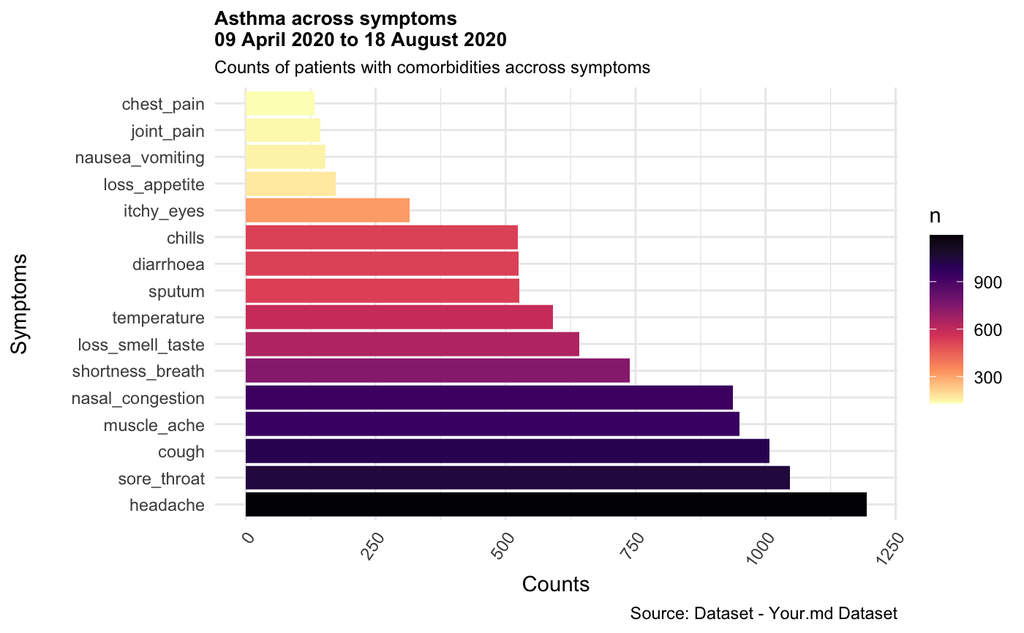

```r
asthma_count <- asthma_data %>%
  tidyr::pivot_longer(cols = 2:17,
                      names_to = "symptoms",
                      values_to = "yes_no") %>%
  dplyr::filter(asthma == "Yes" & yes_no == "Yes") %>%
  dplyr::group_by(symptoms) %>%
  dplyr::tally() %>%
  dplyr::mutate(Percentage = n/sum(n)) %>%
  dplyr::arrange(desc(n))

start_date = as.Date("2020-04-09", tz = "Europe/London")
end_date = as.Date("2020-08-18")
title_stub <- "Asthma across symptoms\n"
start_date_title <- format(as.Date(start_date), format = "%d %B %Y")
end_date_title <- format(as.Date(end_date), format = "%d %B %Y")
chart_title <- paste0(title_stub, start_date_title, " to ", end_date_title)

plot_asthma_sympt <-
  ggplot2::ggplot(asthma_count, ggplot2::aes(x = reorder(symptoms, - Percentage), y = n, fill = n)) +
  ggplot2::coord_flip() +
  ggplot2::geom_bar(stat = "identity", position = "dodge") +
  ggplot2::scale_fill_viridis_c(option = "magma", direction = -1) +
  ggplot2::scale_x_discrete(limits = unique(asthma_count$symptoms)) +
  #ggplot2::theme(legend.position = "bottom") +
  #ggplot2::guides(fill = ggplot2::guide_legend(nrow = 3)) +
  ggplot2::theme_minimal() +
  ggplot2::labs( title = chart_title,
                 subtitle = "Counts of patients with comorbidities accross symptoms",
                 y = "Counts",
                 x = "Symptoms",
                 caption = "Source: Dataset - Your.md Dataset") +
  ggplot2::theme(
    axis.title.y = ggplot2::element_text(margin = ggplot2::margin(
      t = 0,
      r = 21,
      b = 0,
      l = 0
    )),
    plot.title = ggplot2::element_text(size = 10, face = "bold"),
    plot.subtitle = ggplot2::element_text(size = 9),
    axis.text.x = ggplot2::element_text(angle = 55, hjust = 1)
  )

plot_asthma_sympt
```

## Univariate analysis for asthma

Unvivariate analysis reveal chills, cough, diarrhea, headache, muschle ache, sore throat, nausea and vomiting, shortness of breath, sputum, temperature are the associated Covid symptoms in respondents with asthma.

1. Asthma and chills

```
Call:
glm(formula = asthma ~ chills, family = binomial, data = asthma_data)

Deviance Residuals:
   Min      1Q  Median      3Q     Max
-0.369  -0.315  -0.315  -0.315   2.461

Coefficients:
            Estimate Std. Error z value Pr(>|z|)
(Intercept)  -2.9787     0.0201 -148.48  < 2e-16 ***
chillsYes     0.3276     0.0410    7.99  1.3e-15 ***
---
Signif. codes:  0 ‘***’ 0.001 ‘**’ 0.01 ‘*’ 0.05 ‘.’ 0.1 ‘ ’ 1

(Dispersion parameter for binomial family taken to be 1)

    Null deviance: 27145  on 66658  degrees of freedom
Residual deviance: 27084  on 66657  degrees of freedom
AIC: 27088

Number of Fisher Scoring iterations: 5

(Intercept)   chillsYes
      0.051       1.388
```

|  | OR | 2.5 % | 97.5 % |
| --- | --- | --- | --- |
| (Intercept) | 0.05 | 0.05 | 0.05 |
| chillsYes | 1.39 | 1.28 | 1.50 |

2. Asthma and cough

```
Call:
glm(formula = asthma ~ cough, family = binomial, data = asthma_data)

Deviance Residuals:
   Min      1Q  Median      3Q     Max
-0.344  -0.344  -0.312  -0.312   2.468

Coefficients:
            Estimate Std. Error z value Pr(>|z|)
(Intercept)  -2.9978     0.0239 -125.61  < 2e-16 ***
coughYes      0.2030     0.0351    5.79  7.2e-09 ***
---
Signif. codes:  0 ‘***’ 0.001 ‘**’ 0.01 ‘*’ 0.05 ‘.’ 0.1 ‘ ’ 1

(Dispersion parameter for binomial family taken to be 1)

    Null deviance: 27145  on 66658  degrees of freedom
Residual deviance: 27112  on 66657  degrees of freedom
AIC: 27116

Number of Fisher Scoring iterations: 5
```

|  | OR | 2.5 % | 97.5 % |
| --- | --- | --- | --- |
| (Intercept) | 0.05 | 0.05 | 0.05 |
| coughYes | 1.23 | 1.14 | 1.31 |

3. Asthma and diarrhea

```
Call:
glm(formula = asthma ~ diarrhoea, family = binomial, data = asthma_data)

Deviance Residuals:
   Min      1Q  Median      3Q     Max
-0.361  -0.317  -0.317  -0.317   2.456

Coefficients:
             Estimate Std. Error z value Pr(>|z|)
(Intercept)   -2.9662     0.0200 -148.27  < 2e-16 ***
diarrhoeaYes   0.2690     0.0412    6.53  6.7e-11 ***
---
Signif. codes:  0 ‘***’ 0.001 ‘**’ 0.01 ‘*’ 0.05 ‘.’ 0.1 ‘ ’ 1

(Dispersion parameter for binomial family taken to be 1)

    Null deviance: 27145  on 66658  degrees of freedom
Residual deviance: 27104  on 66657  degrees of freedom
AIC: 27108

Number of Fisher Scoring iterations: 5
```

```r
knitr::kable(exp(cbind(OR = coef(asthma_diarrhea), confint(asthma_diarrhea))))
```

[output not shown]

4. Asthma and headache

```
Call:
glm(formula = asthma ~ headache, family = binomial, data = asthma_data)

Deviance Residuals:
   Min      1Q  Median      3Q     Max
-0.345  -0.345  -0.308  -0.308   2.478

Coefficients:
            Estimate Std. Error z value Pr(>|z|)
(Intercept)  -3.0218     0.0252  -120.1  < 2e-16 ***
headacheYes   0.2311     0.0350     6.6  4.1e-11 ***
---
Signif. codes:  0 ‘***’ 0.001 ‘**’ 0.01 ‘*’ 0.05 ‘.’ 0.1 ‘ ’ 1

(Dispersion parameter for binomial family taken to be 1)

    Null deviance: 27145  on 66658  degrees of freedom
Residual deviance: 27101  on 66657  degrees of freedom
AIC: 27105

Number of Fisher Scoring iterations: 5
```

```r
knitr::kable(exp(cbind(OR = coef(asthma_headache), confint(asthma_headache))))
```

[output not shown]

5. Asthma and loss of smell and taste

```
Call:
glm(formula = asthma ~ loss_smell_taste, family = binomial, data = asthma_data)

Deviance Residuals:
   Min      1Q  Median      3Q     Max
-0.332  -0.332  -0.332  -0.312   2.468

Coefficients:
                    Estimate Std. Error z value Pr(>|z|)
(Intercept)          -2.8712     0.0207 -138.96   <2e-16 ***
loss_smell_tasteYes  -0.1260     0.0388   -3.25   0.0012 **
---
Signif. codes:  0 ‘***’ 0.001 ‘**’ 0.01 ‘*’ 0.05 ‘.’ 0.1 ‘ ’ 1

(Dispersion parameter for binomial family taken to be 1)

    Null deviance: 27145  on 66658  degrees of freedom
Residual deviance: 27134  on 66657  degrees of freedom
AIC: 27138

Number of Fisher Scoring iterations: 5
```

|  | OR | 2.5 % | 97.5 % |
| --- | --- | --- | --- |
| (Intercept) | 0.06 | 0.05 | 0.06 |
| loss_smell_tasteYes | 0.88 | 0.82 | 0.95 |

6. Asthma and muscle ache

```
Call:
glm(formula = asthma ~ muscle_ache, family = binomial, data = asthma_data)

Deviance Residuals:
   Min      1Q  Median      3Q     Max
-0.351  -0.351  -0.310  -0.310   2.473

Coefficients:
               Estimate Std. Error z value Pr(>|z|)
(Intercept)     -3.0101     0.0230 -130.67   <2e-16 ***
muscle_acheYes   0.2569     0.0354    7.26    4e-13 ***
---
Signif. codes:  0 ‘***’ 0.001 ‘**’ 0.01 ‘*’ 0.05 ‘.’ 0.1 ‘ ’ 1

(Dispersion parameter for binomial family taken to be 1)

    Null deviance: 27145  on 66658  degrees of freedom
Residual deviance: 27093  on 66657  degrees of freedom
AIC: 27097

Number of Fisher Scoring iterations: 5
```

|  | OR | 2.5 % | 97.5 % |
| --- | --- | --- | --- |
| (Intercept) | 0.05 | 0.05 | 0.05 |
| muscle_acheYes | 1.29 | 1.21 | 1.39 |

7. Asthma and nasal congestion

```
Call:
glm(formula = asthma ~ nasal_congestion, family = binomial, data = asthma_data)

Deviance Residuals:
   Min      1Q  Median      3Q     Max
-0.341  -0.341  -0.316  -0.316   2.458

Coefficients:
                    Estimate Std. Error z value Pr(>|z|)
(Intercept)          -2.9698     0.0228 -130.38  < 2e-16 ***
nasal_congestionYes   0.1560     0.0355    4.39  1.1e-05 ***
---
Signif. codes:  0 ‘***’ 0.001 ‘**’ 0.01 ‘*’ 0.05 ‘.’ 0.1 ‘ ’ 1

(Dispersion parameter for binomial family taken to be 1)

    Null deviance: 27145  on 66658  degrees of freedom
Residual deviance: 27126  on 66657  degrees of freedom
AIC: 27130

Number of Fisher Scoring iterations: 5
```

|  | OR | 2.5 % | 97.5 % |
| --- | --- | --- | --- |
| (Intercept) | 0.05 | 0.05 | 0.05 |
| nasal_congestionYes | 1.17 | 1.09 | 1.25 |

8. Athma and nausea and vomiting

```
Call:
glm(formula = asthma ~ nausea_vomiting, family = binomial, data = asthma_data)

Deviance Residuals:
   Min      1Q  Median      3Q     Max
-0.391  -0.322  -0.322  -0.322   2.443

Coefficients:
                   Estimate Std. Error z value Pr(>|z|)
(Intercept)         -2.9331     0.0182  -161.5  < 2e-16 ***
nausea_vomitingYes   0.3980     0.0674     5.9  3.6e-09 ***
---
Signif. codes:  0 ‘***’ 0.001 ‘**’ 0.01 ‘*’ 0.05 ‘.’ 0.1 ‘ ’ 1

(Dispersion parameter for binomial family taken to be 1)

    Null deviance: 27145  on 66658  degrees of freedom
Residual deviance: 27113  on 66657  degrees of freedom
AIC: 27117

Number of Fisher Scoring iterations: 5
```